# Bioinformatics, interpretation and data quality assurance in genome analysis:NGS Galaxy Workshop

Dr Stephen J Newhouse

**Contact:**(+44) 07967741721, stephen.newhouse@kcl.ac.uk, stephen.j.newhouse@gmail.com

**Important: This document is best viewed as a html file in any web browser**

# Overview

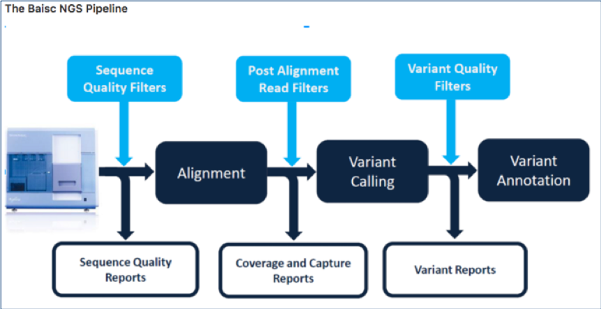

**Basic analysis of NGS data for clinical genetics involves the following basic steps:**

- quality control
- alignment (read mapping)
- variant calling
- variant annotation
- variant prioritisation
- *reporting*

It is essential to assess data quality and performance at each step.

**At the end of this workshop you will be able to:**

1. Use the Galaxy suite of bioinformatic tools
2. Assess the quality of raw NGS data in fastq format prior to alignment
3. Align NGS data to the reference human genome using BWA
4. Describe the contents of Fastq, SAM and BAM files
5. Make an assessment of the alignment process
6. Conduct quality control filtering of reads
7. Visualise aligned data
8. Call variants and conduct quality control filtering and annotation of variants
9. Prioritise variants for follow-up/clinical reporting

## Note

**Work through this document at your own pace.**  
**Please read everything carefully. Ask questions and have fun!**

At the begining of some of the sections I list the main software called by Galaxy and their basic input and output and output formats.

## WARNING!

Galaxy is an ongoing project, bioinformatics software are still being developed, fixed, tweaked and improved upon. As a result, some of the screenshots in the document may not exactly match what you see on the live usegalaxy.com website or the Galaxy instance we provide on the Genomics England compute environment. Software versions may differ also. Don’t panic. Keep calm. The workflow/pipeline and tools we use will stay the same - there may just be some subtle differences. Use the search bar in Galaxy to find the tool you need. Ask questions. Google it. Report any bugs and typos.

## The main bioinformatic software used in this workshop

- Galaxy : https://usegalaxy.org/
- fastqc : https://www.bioinformatics.babraham.ac.uk/projects/fastqc/
- trimmomatic : http://www.usadellab.org/cms/?page=trimmomatic
- bwa : http://bio-bwa.sourceforge.net/
- samtools : http://www.htslib.org/
- picard : http://broadinstitute.github.io/picard/
- bedtools : http://bedtools.readthedocs.io/en/latest/
- IGV : http://software.broadinstitute.org/software/igv/
- freebayes : https://github.com/ekg/freebayes
- vcflib : https://github.com/vcflib/vcflib
- ANNOVAR : http://annovar.openbioinformatics.org/en/latest/
- wANNOVAR : http://wannovar.wglab.org/

# The NGS Workshop Data

The sequence data that you will be analysing is from a 3-year-old male who presented with difficulty walking after the first year of life, followed by signs of muscle wasting and weakness, muscle rigidity, developmental delays, progressive loss of vision leading to blindness, convulsions, impaired swallowing, paralysis, and dementia. An MRI scan showed a “tigroid” or “leopard-skin” appearance within the deep white matter - recognizable abnormalities of white matter. Further clinical tests suggest a diagnosis of [Metachromatic leukodystrophy](https://ghr.nlm.nih.gov/condition/metachromatic-leukodystrophy#) (MLD, also called Arylsulfatase A deficiency): is a lysosomal storage disease which is commonly listed in the family of leukodystrophies as well as among the sphingolipidoses as it affects the metabolism of sphingolipids.

The patient’s exome was sequenced using the paired-end method on an [Illumina HiSeq 2500](https://www.illumina.com/systems/hiseq_2500_1500.html) following target enrichment using the [Nextera Rapid Capture Exome and Expanded Exome kit](https://www.illumina.com/products/by-type/sequencing-kits/library-prep-kits/nextera-rapid-capture-exome.html).

*This data is simulated - but it does represents a real life scenario*

**Illumina Sequencing**

- Illumina [Screencast](https://vimeo.com/121178846)
- Illumina [Slides](https://depot.galaxyproject.org/hub/attachments/documents/presentations/NGS101-Illumina.pdf)

**Publications:**

- [Human genome sequencing on Illumina - Bentley et al. (2008)](http://www.nature.com/nature/journal/v456/n7218/pdf/nature07517.pdf)
- [Illumina pitfalls - Kircher et al. (2011)](http://www.biomedcentral.com/content/pdf/1471-2164-12-382.pdf)
- [Data quality 1 - Minoche et al. (2011)](http://genomebiology.com/content/pdf/gb-2011-12-11-r112.pdf)
- [Data quality 2 - Nakamura et al. (2010)](http://nar.oxfordjournals.org/content/39/13/e90.full-text-lowres.pdf)

## Getting the Data

1. Create local folder on your computer called `workshop_data_2018` (or something memorable)
2. Download the test data from the links provided below

**The Workshop Data**

| FILE | DESCRIPTION | URL |
| --- | --- | --- |
| WES01_chr22m_R1.fastq.gz | Illumina fastq file read 1 | **[click me](https://s3-eu-west-1.amazonaws.com/workshopdata2017/WES01_chr22m_R1.fastq.gz)** |
| WES01_chr22m_R2.fastq.gz | Illumina fastq file read 2 | **[click me](https://s3-eu-west-1.amazonaws.com/workshopdata2017/WES01_chr22m_R2.fastq.gz)** |
| chr22.genes.hg19.bed | annotation bed file | **[click me](https://s3-eu-west-1.amazonaws.com/workshopdata2017/chr22.genes.hg19.bed)** |

**You should have a folder that looks somthing like:-**

[figure not shown]

# 1. Galaxy

You will be using Galaxy to construct and run your NGS pipeline. Galaxy is an open source, web-based platform for data intensive biomedical research. If you are new to Galaxy start here and/or consult the help resources:

**Learning Resources**

- **Galaxy NGS 101: https://wiki.galaxyproject.org/Learn/GalaxyNGS101**  
  This page is designed to serve as a comprehensive resource describing manipulation and analysis of NGS data. While it is designed to highlight the utility of Galaxy it will also provide information that is broadly applicable and can be used for teaching of big data biology. It is accompanied by a collection of [screencasts](https://vimeo.com/channels/884356).

**Getting more help on Galaxy**

- **Use Galaxy Biostars:** https://biostar.usegalaxy.org/
- **Galaxy Wiki and Tutorials: https://wiki.galaxyproject.org/Support**  
  .

## 1.1 Sign in to Galaxy

**You should have all registered for a Galaxy account!**

1. Go to https://usegalaxy.org/ and sign in

### INFO: The Galaxy Interface

- The available “Tools” are in the left tool pane.
- The central panel is your working area where you can visualise your data, select tool options and execute jobs.
- Your “History” is shown in the right hand panel. Here you will see your data, results and a history of all the tools that you have used.

[figure not shown]

### INFO: The Galaxy Tool Interface

A lot of useful information is displayed in the centre panel. Don’t ignore it!

An example is shown below. This is for the software Freebayes: a Bayesian genetic variant detector designed to find small polymorphisms, specifically SNPs (single-nucleotide polymorphisms), indels (insertions and deletions), MNPs (multi-nucleotide polymorphisms), and complex events (composite insertion and substitution events) smaller than the length of a short-read sequencing alignment.

- **Tool name, Galaxy Version, and tool version selector and other galaxy options**
- **Tool options** e.g. set input files, reference genome version, tool specific parameters and execute.
- **What it does**
- **Description**
- **Galaxy-specific options**
- **Acknowledgments**
- **Citations**

**You will get used to this as you work through the workshop**

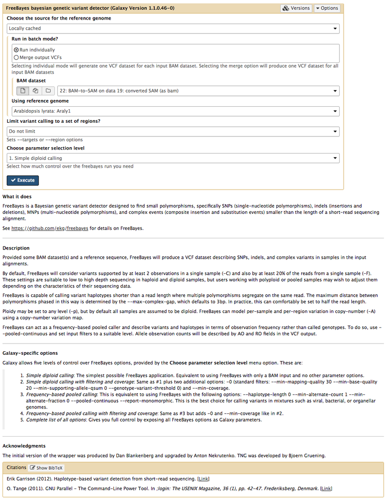

## 1.2 Start a new Galaxy History

1. Rename the history for this session (Click on name, type new name, press return)
2. Use the Name: **WES01 NGS Workshop** .

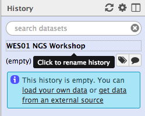

## 1.3 Load the Data

- Click **Get Data > Upload File** .

[figure not shown]

- Click **Chose local file** .

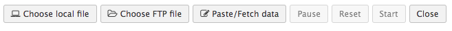

- Navigate to **`workshop_data_2018`** on your local computer and select all 3 files and click **open** .

[figure not shown]

- The files will appear in the **Download from web or upload from disk** window .

[figure not shown]

- You now need to tell Galaxy what type of data these are and what version of the human genome reference we wish to use .

### INFO: The NGS Data Files and Formats

**Paired End Sequence data : FASTQ Format**

One lane of paired end sequencing was performed so you have two files of raw sequence data (**WES01_chr22m_R1.fastq.gz** and **WES01_chr22m_R2.fastq.gz**) which contain all the sequence data for read 1 (R1) and read 2 (R2) respectively (Figure: Paired End Sequence data). To save on computing time and disk space, the NGS data for WES01 has been filtered to contain reads mapping to chromosome 22 only and the files have been compressed (hence the .gz extension).

**Figure: Paired End Sequence data**

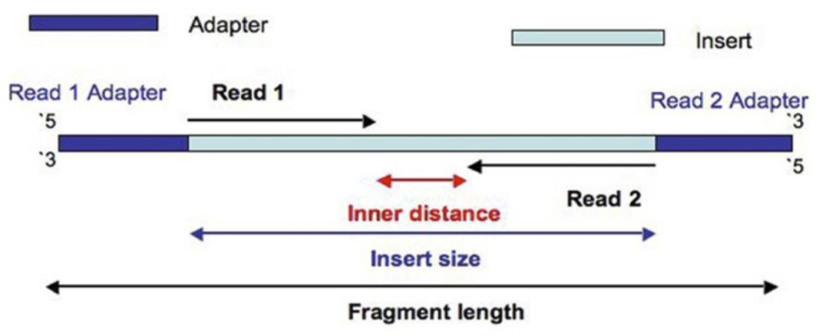

The raw NGS data is held in fastq format: http://en.Wikipedia.org/wiki/FASTQ_format. Fastq files are the simplest and most generic way of storing read sequences and qualities.

- Line 1 begins with a ‘@’ character and is followed by a sequence identifier and an optional description (like a FASTA title line).
- Line 2 is the raw sequence letters.
- Line 3 begins with a ‘+’ character and is optionally followed by the same sequence identifier (and any description) again.
- Line 4 encodes the quality values for the sequence in Line 2, and must contain the same number of symbols as letters in the sequence.

**Figure: Fastq Data**

```
@HWI-D00119:50:H7AP8ADXX:1:1212:10369:36657/1
GCACGTGGGTTCCCAGTAGCAAGAAACTAAAGGGTCGCAGGCCGGTTTCTGCTAATTTCTTTAATTCCAAGACAGTCTCAAATATTTTCTTATTAACTTCC
+
CCCFFFFFHHHHHJJJHIJJJJJJJJJJJJJJJJHFGIIIGJJJJIIHHHHHHFFFFFFFEEEEEEEEEDDDDDDDDDDEDDDDFFEEEDDDDEEEDDEDD
```

**Illumina sequence identifiers**

Sequences from the Illumina software use a systematic identifier.

`@EAS139:136:FC706VJ:2:2104:15343:197393 1:Y:18:ATCACG`

| Value | Description |
| --- | --- |
| EAS139 | the unique instrument name |
| 136 | the run id |
| FC706VJ | the flowcell id |
| 2 | flowcell lane |
| 2104 | tile number within the flowcell lane |
| 15343 | ‘x’-coordinate of the cluster within the tile |
| 197393 | ‘y’-coordinate of the cluster within the tile |
| 1 | the member of a pair, 1 or 2 (paired-end or mate-pair reads only) |
| Y | Y if the read is filtered, N otherwise |
| 18 | 0 when none of the control bits are on, otherwise it is an even number |
| ATCACG | index sequence |

Note that more recent versions of Illumina software output a sample number (as taken from the sample sheet) in place of an index sequence. For example, the following header might appear in the first sample of a batch:

`@EAS139:136:FC706VJ:2:2104:15343:197393 1:N:18:1`

**Phred Quality Scores**

[A Phred quality score](https://en.wikipedia.org/wiki/Phred_quality_score) is a measure of the quality of the identification of the sequence of bases generated by automated DNA sequencing.

A phred score or quality value Q is an integer mapping of p (i.e., the probability that the corresponding base call is incorrect).

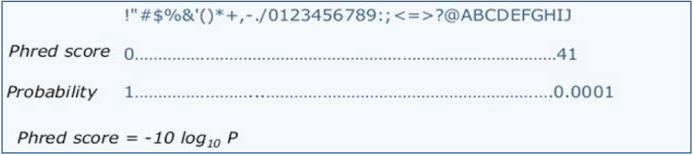

- https://en.Wikipedia.org/wiki/FASTQ_format#Quality
- https://en.Wikipedia.org/wiki/FASTQ_format#Encoding

It is more efficient to store the sequence quality scores as characters because they require less disk space than numbers (i.e. 1 character versus multiple digits). Characters are also more reliable and portable than numbers. Sequence quality scores on the phred scale are determined by mapping the ASCII character to its associated number.

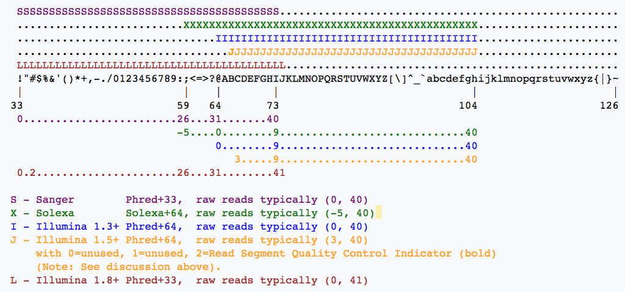

**BED File Annotaion data: chr22.genes.hg19.bed**

Briefly, the BED format consists of one line per feature, each containing 3-12 columns of data, plus optional feature definition lines. A minimal **.bed** file uses 3-4 tab delimited columns of data to describe the target:

The first three fields in each feature line are required:

1. **chrom** - name of the chromosome or scaffold. Any valid seq_region_name can be used, and chromosome names can be given with or without the ‘chr’ prefix.
2. **chromStart** - Start position of the feature in standard chromosomal coordinates (i.e. first base is 0).
3. **chromEnd** - End position of the feature in standard chromosomal coordinates
4. **name** - Label to be displayed under the feature, if turned on in “Configure this page”.
- a quick look at `chr22.genes.hg19.bed`

```
chr22   16256331    16256677    POTEH-chr22-16256332-16256677
chr22   16258184    16258303    POTEH-chr22-16258185-16258303
chr22   16266928    16267095    POTEH-chr22-16266929-16267095
chr22   16269872    16269943    POTEH-chr22-16269873-16269943
chr22   16275206    16275277    POTEH-chr22-16275207-16275277
chr22   16277747    16277885    POTEH-chr22-16277748-16277885
chr22   16279194    16279301    POTEH-chr22-16279195-16279301
chr22   16287253    16287937    POTEH-chr22-16287254-16287937
chr22   16448825    16449804    OR11H1-chr22-16448826-16449804
chr22   17071647    17073700    CCT8L2-chr22-17071648-17073700
```

## 1.4 Set Data Type and Genome Build

1. Set the data type for each data set. Click **Type** and select the data format from the drop down menu:  
   i. **`chr22.genes.hg19.bed` Type = `bed`**  
   ii. **`WES01_chr22m_R1.fastq.gz` Type = `fastqsanger`**  
   iii. **`WES01_chr22m_R2.fastq.gz`Type = `fastqsanger`**
2. Select **Genome (set all):** from the bottom right of the upload data window
3. From the drop-down menu, start typing `hg19` and select **Human Feb. 2009 (GRCh37/hg19)**
4. Click **Start**. .

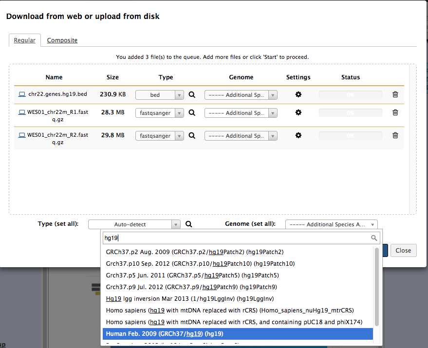

- The data will begin to upload to your session. You will see the green progress bar “Adding to history”. This will take a few minutes (or longer, depending on network speeds and the number of other users logged in world wide!). .

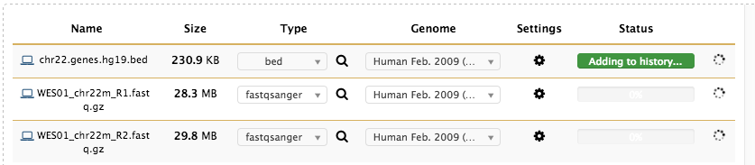

- When the data has finished uploading, click **Close**. .

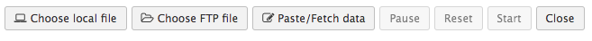

- The uploaded data will appear in the history panel:- .

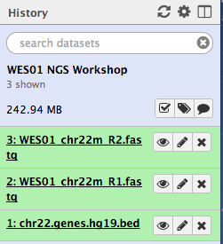

- You can view the raw data by clicking on the **eye** icon .

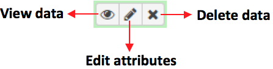

# 2. Pre-Alignment QC

**Software**

**Tools**

- fastqc
- trimmomatic

**Input/Output**

- fastqc input: raw fastq files
  - WES01_chr22m_R1.fastq.gz
  - WES01_chr22m_R2.fastq.gz
- fastqc output: html and text file
- trimmomatic input:
  - Nextera adapter sequences (provided by galaxy)
  - WES01_chr22m_R1.fastq.gz
  - WES01_chr22m_R2.fastq.gz
- trimmomatic output: quality trimmed fastq files (4 files)
  - trimmomatic WES01_chr22m_R1.fastq.gz (paired)
  - trimmomatic WES01_chr22m_R2.fastq.gz (paired)
  - trimmomatic WES01_chr22m_R1.fastq.gz (unpaired)
  - trimmomatic WES01_chr22m_R2.fastq.gz (unpaired)

## 2.1 Pre-Alignment QC: View fastq data files

[FASTQ_Format](https://en.wikipedia.org/wiki/FASTQ_format): A FASTQ file normally uses four lines per sequence.

Line 1 begins with a ‘@’ character and is followed by a sequence identifier and an optional description (like a FASTA title line).  
Line 2 is the raw sequence letters.  
Line 3 begins with a ‘+’ character and is optionally followed by the same sequence identifier (and any description) again.  
Line 4 encodes the quality values for the sequence in Line 2, and must contain the same number of symbols as letters in the sequence.

- To view your raw fastq data click on the eye icon .

[figure not shown]

**Illumina sequence identifiers**

Sequences from the Illumina software use a systematic identifier:

`@HWUSI-EAS100R:6:73:941:1973#0/1`

| ID | Description |
| --- | --- |
| HWUSI-EAS100R | the unique instrument name |
| 6 | flowcell lane |
| 73 | tile number within the flowcell lane |
| 941 | ‘x’-coordinate of the cluster within the tile |
| 1973 | ‘y’-coordinate of the cluster within the tile |
| #0 | index number for a multiplexed sample (0 for no indexing) |
| /1 | the member of a pair, /1 or /2 (paired-end or mate-pair reads only) |

Versions of the Illumina pipeline since 1.4 appear to use #NNNNNN instead of #0 for the multiplex ID, where NNNNNN is the sequence of the multiplex tag.

With Casava 1.8 the format of the ‘@’ line has changed:

`@EAS139:136:FC706VJ:2:2104:15343:197393 1:Y:18:ATCACG`

| ID | Description |
| --- | --- |
| EAS139 | the unique instrument name |
| 136 | the run id |
| FC706VJ | the flowcell id |
| 2 | flowcell lane |
| 2104 | tile number within the flowcell lane |
| 15343 | ‘x’-coordinate of the cluster within the tile |
| 197393 | ‘y’-coordinate of the cluster within the tile |
| 1 | the member of a pair, 1 or 2 (paired-end or mate-pair reads only) |
| Y | Y if the read is filtered, N otherwise |
| 18 | 0 when none of the control bits are on, otherwise it is an even number |
| ATCACG | index sequence |

Note that more recent versions of Illumina software output a sample number (as taken from the sample sheet) in place of an index sequence. For example, the following header might appear in the first sample of a batch:

`@EAS139:136:FC706VJ:2:2104:15343:197393 1:N:18:1`

- View the fastq data files and make a note of the following information: .

1. The unique instrument name  
2. The run id  
3. The flowcell id  
4. The flowcell lane

- This can all be obtained from the sequence identifier i.e. line 1 of the first fastq entry:- .

**Fastq Header Explaination**

```
Header: @HWI-D00119:50:H7AP8ADXX:1:1212:10369:36657/1
            |       |     |      |
mapping:    1       2     3      4
```

1. The unique instrument name: **HWI-D00119**
2. The run id: **50**
3. The flowcell id: **H7AP8ADXX**
4. The flowcell lane: **1**
- We will use this later to add meta data (i.e. read group information) and sample information to our NGS analysis. .

## 2.2 Pre-Alignment QC: Assess the quality of raw sequence data

To assess the quality of the raw sequence data and to guide quality control we will use a program called **FastQC**. The program outputs summary graphs and tables that show if there are any problem areas, which could influence assembly or variant calling if not addressed.

You can learn more about the program here (http://www.bioinformatics.babraham.ac.uk/projects/fastqc/).

1. In Tool Pane: Go to NGS: QC and manipulation > FastQC Read Quality reports
2. Select multiple datasets, highlight both fastq files and click Execute .

[figure not shown]

The FastQC reports will be shown in the History Pane. Queued jobs in grey with a clock symbol, running jobs in yellow with a buffering symbol, finished jobs in green, failed jobs in red with a cross. .

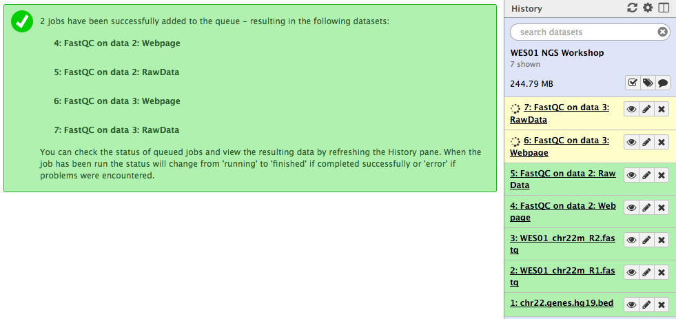

[figure not shown]

1. How many reads do the files contain?
2. How long are the reads (bp)?
3. Has either file failed any of the sequence quality checks?

### INFO: Per base sequence quality for WES01_chr22m_R1.fastq

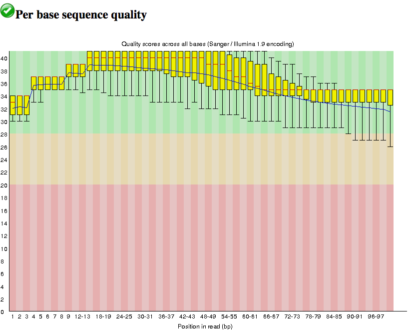

Looking at the per base sequence quality you will notice that the average base quality drops towards the end of reads (Figure above). This drop in quality is typical for ensemble-based sequencing by synthesis (SBS) methods, such as Illumina, which add complimentary bases one at a time in a cluster of identical sequences to determine a consensus sequence from the ‘average’ sequence signal over all copies in the cluster. As nucleotides are added some of the sequences in a cluster grow at a different rate and become desynchronized which reduces the accuracy of the ‘average’ sequence signal

### INFO: Read-length and phasing (From Fuller et al. 2009: Nat Biotechnol. doi: 10.1038/nbt)

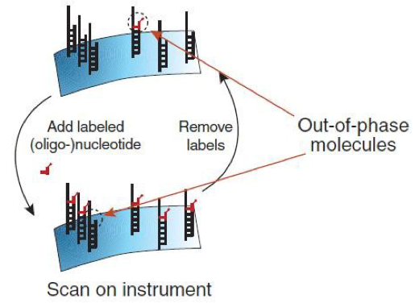

Another particularly important plot is that of ‘Overrepresented sequences’, which lists sequences that account for more than 0.1% of the total. The presence of an overrepresented sequence suggests that the sequence is biologically significant, or that the library is contaminated or has low diversity. To check for contamination, each overrepresented sequence is compared to a database of common contaminants such as sequencing adaptors which can then be removed from the raw FastQ data.

## 2.3 Pre-Alignment QC: Filter reads based on quality

In a typical analysis you may want to raise technical issues identified by FastQC such as low read count, poor quality, and overrepresented sequences with the data provider. To ensure that only data of a certain quality is used for further analysis we will exclude low quality reads. In paired-end data there are two fastq files per lane of sequencing which are synchronised so that matching pairs are stored in the same line of each file (e.g. the read in line 1, file 1 is paired with the read in line 1, file 2 and so on).

To maintain this order when filtering, we will filter the fastq files using TRIMMOMATIC (Bolger, A. M., Lohse, M., & Usadel, B. (2014). Trimmomatic: A flexible trimmer for Illumina Sequence Data. Bioinformatics, btu170.) the fastq files need to be joined and the reads have to be removed as a pair.

- In Tool Pane: Go to NGS: QC and manipulation > Trimmomatic
- Select the two reads .

[figure not shown]

- Select YES for Perform initial ILLUMINACLIP step?
- In the dropdown box select Nextera (paired-end) .

**Nextera adapters are:**

```
- Read1  CTGTCTCTTATACACATCTCCGAGCCCACGAGAC
- Read2  CTGTCTCTTATACACATCTGACGCTGCCGACGA
```

**Additional Reference:** [what-sequences-do-i-use-for-adapter-trimming](https://support.illumina.com/bulletins/2016/12/what-sequences-do-i-use-for-adapter-trimming.html)

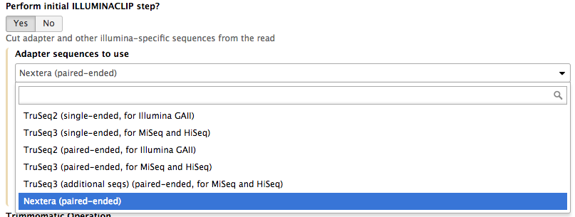

### 2.3.1 Trimmomaitc Operations

- Keep the first Trimmomatic Operation: Sliding Window trimming
- Add an additional Trimmomatic Operation QC step
- Under Trimmomatic Operation, Click: + Insert Trimmomatic Operation .

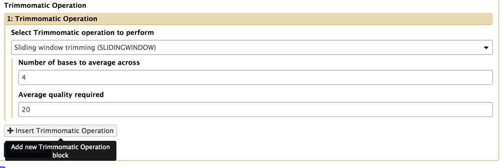

- Select > Drop reads below a specified length (MINLEN) set this to 50 .

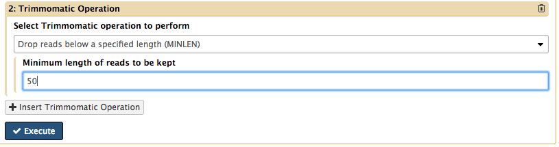

**You should now have set up 2 Trimmomatic Operations**

1. Sliding Window (number of bases:4, average quality 20)
2. Drop reads below a specified length (50bp)
- Click Execute .

For paired-end data a particular strength of Trimmomatic is that it retains the pairing of reads (from R1 and R2) in the filtered output files:

Two FASTQ files (R1-paired and R2-paired) contain one read from each pair where both have survived filtering. Additionally two FASTQ files (R1-unpaired and R2-unpaired) contain reads where one of the pair failed the filtering steps.

When the job has successsfully run you should see something like:

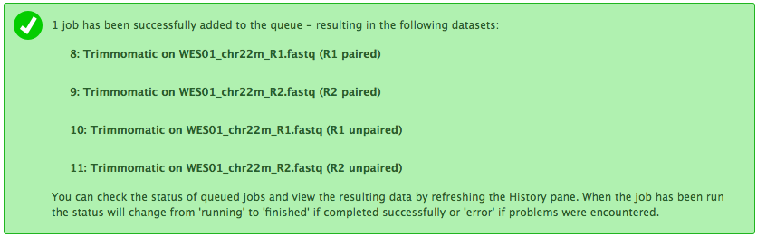

## 2.4 Rerun FastQC on the filtered reads to see the effect of filtering.

- In Tool Pane: Go to NGS: QC and manipulation > FastQC Read Quality reports
- Select > 8: Trimmomatic on WES01_chr22m_R1.fastq (R1 paired) and 9: Trimmomatic on WES01_chr22m_R2.fastq (R2 paired)
- Execute .

[figure not shown]

- Look at the results for the paired files (e.g 12 FastQC on data 8: Webpage) : .

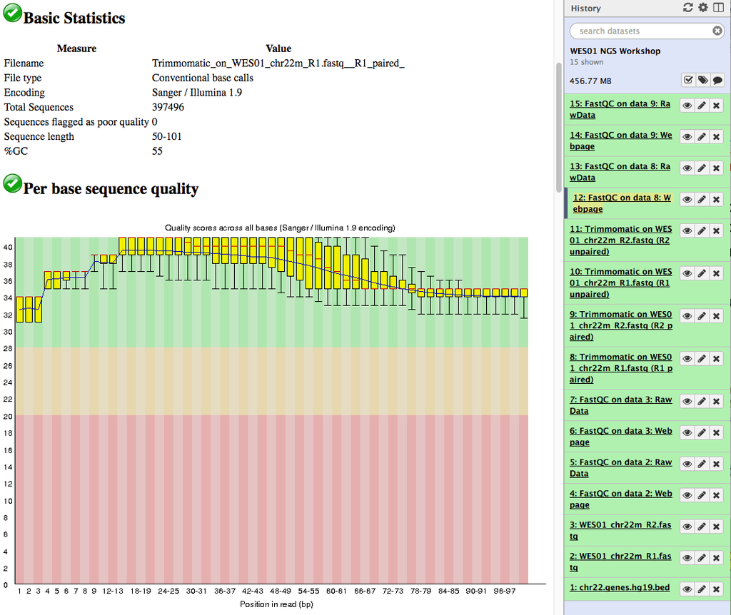

1. How many reads do the files contain?
2. How long are the reads (bp) and is the quality distribution better? There are other ways to clean up reads such as trimming or filtering by other criteria that could be used depending on the data quality and requirements.

# 3. Alignment

**Software**

**Tools**

- bwa

**Input/Output**

- bwa input: Reference Genome and indexes for use with bwa (provided by galaxy)
  - hg19 (fasta file)
  - bwa indexes:
    - .amb is text file, to record appearance of N (or other non-ATGC) in the ref fasta.
    - .ann is text file, to record ref sequences, name, length, etc.
    - .bwt is binary, the Burrows-Wheeler transformed sequence.
    - .pac is binary, packaged sequence (four base pairs encode one byte).
    - .sa is binary, suffix array index.
- bwa input: paired fastq files
  - trimmomatic WES01_chr22m_R1.fastq.gz (paired)
  - trimmomatic WES01_chr22m_R2.fastq.gz (paired)
- bwa output: SAM/BAM file
  - BAM file
  - BAI (BAM Index: automatically produced by galaxy)

## 3.1 Alignment: Align sequence data to the reference human genome

We will use a program called BWA-MEM (Burrows-Wheeler Alignment) to align the sequence data to the human genome. You can learn more about the bwa program here (http://bio-bwa.sourceforge.net/).